# **"The Warriors' Home and Away Gap"**

By: Eric Youmans, Nebil Ozer, Nadula Kadawedduwa

### **Introduction**

Coming into the 2022-2023 season the Golden State Warriors were the defending champions. They finished the 2021-2022 regular season as the 3rd seed in the Western Confrence and they managed to exceed most expectations by making a championship run in the playoffs.

While there are more factors, one would expect the defending champions to be one of the better teams in the NBA. However, the Warriors this regular season (2022-2023) finished only slightly above a 50% winning rate. Variance between seasons is not uncommon but there is something especially intresting about the Warrior this season. They have one of the best home records in the league, but one of the worst road records, being an outlier even with this season having one of the highest home-road splits in NBA history (https://sircharlesincharge.com/2023/01/13/nba-road-splits-staggering/).

Our goal is to establish that the GSW's Home-Road split is indeed statistically significant, find out why it is as large as it is, and where the Golden State Warriors need to improve in their "on the road" games if they hope to do better next season.

First we will import our data and prepare it for use. Then we will visualize the gap, and find where exactly the changes are in the performance of the Warriors at home and on the road. Afterwards, we will attempt to use these stats to make a predicitive model on The Golden State Warriors' home/road record.

Throughout this analysis, we made use of the data collected in the following two pages, readily available as CSV files:

https://www.nbastuffer.com/2022-2023-nba-team-stats/

https://www.basketball-reference.com/leagues/NBA_2023.html#all_confs_standings_E

Due to the NBA having very well-documented statistics and a wealth of data to choose from, we were able to obtain our data very easily.

### Note:

team stats are all abbreviated within the code and output. Although we will type out each statistic we use for clarity, here is a helpful glossary that explains what each stat means:

[figure not shown]

Image from: https://www.nbastuffer.com/2022-2023-nba-team-stats/

### Importing Necessary Libraries

```python
import pandas as pd
import matplotlib.pyplot as plt
import numpy as np
import seaborn as sns
import statsmodels.formula.api as smf
from bs4 import BeautifulSoup
import requests
import re
import math
```

### Importing Necessary Data

```python
home = pd.read_csv('./home.csv')
road = pd.read_csv('./road.csv')
both = pd.read_csv('./home&road.csv')
```

**Merging Our Datasets**

All we are doing here is making a Pandas dataframe that has all the stats from the 'both' datatset but also includes Home Win% and Road Win%. We will use this dataframe for visualization and use the advanced dataframe for more in depth analysis once we know what teams we want to look into.

```python
dfhome = pd.DataFrame()
dfroad = pd.DataFrame()
dfhome['TEAM'] = home['TEAM']
dfhome['Home Win%'] = home['WIN%']
dfroad['TEAM'] = road['TEAM']
dfroad['Road Win%'] = road['WIN%']
merged_df = dfhome.merge(dfroad, on='TEAM')
df = both.merge(merged_df, on='TEAM')
df.head()
```

|  | RANK | TEAM | CONF | DIVISION | GP | PPG | oPPG | pDIFF | PACE | oEFF | ... | A4F | W | L | WIN% | eWIN% | pWIN% | ACH | STRK | Home Win% | Road Win% |
| --- | --- | --- | --- | --- | --- | --- | --- | --- | --- | --- | --- | --- | --- | --- | --- | --- | --- | --- | --- | --- | --- |
| 0 | 1 | Milwaukee | East | Central | 82 | 116.9 | 113.3 | 3.6 | 100.5 | 115.5 | ... | 0.086 | 58 | 24 | 0.707 | 0.595 | 0.619 | 0.112 | -2 | 0.780 | 0.634 |
| 1 | 2 | Boston | East | Atlantic | 82 | 117.9 | 111.4 | 6.5 | 98.4 | 118.1 | ... | 0.063 | 57 | 25 | 0.695 | 0.677 | 0.714 | 0.018 | 3 | 0.780 | 0.610 |
| 2 | 3 | Philadelphia | East | Atlantic | 82 | 115.2 | 110.9 | 4.3 | 96.8 | 117.8 | ... | 0.021 | 54 | 28 | 0.659 | 0.629 | 0.642 | 0.030 | 2 | 0.707 | 0.610 |
| 3 | 4 | Cleveland | East | Central | 82 | 112.3 | 106.9 | 5.4 | 95.6 | 116.2 | ... | 0.004 | 51 | 31 | 0.622 | 0.667 | 0.678 | -0.045 | -1 | 0.756 | 0.488 |
| 4 | 5 | New York | East | Atlantic | 82 | 116.0 | 113.1 | 2.9 | 97.1 | 117.8 | ... | 0.021 | 47 | 35 | 0.573 | 0.589 | 0.595 | -0.016 | -2 | 0.561 | 0.585 |

5 rows × 26 columns

## **Visualization and Showcasing the Problem:** 🏀🏀

Below we visualized the Teams with the most and least wins in Total, At Home and lastly on the Road.

### Total Win %

We found that Golden State's total WP (Win Percentage) is 53.7%, their home WP is 80.5% (The third highest in the NBA), and their road WP is 26.8% (The fourth lowest in the NBA). The teams with the highest total WP include Milwaukee, Boston, Philadephia, Denver, Clevland, and Memphis, and they have been marked as Green on all four plots. The teams with the lowest total WP include Charlotte, Houston, San Antonio, and Detroit, which have been marked with Red on all four plots.

### Home Win %

The teams with the highest Home WP are Memphis, Denver, Golden State, Boston, Milwaukee, Clevland, and Philadelphia. All of these teams are also included in the teams with the total WP besides Golden State. The teams with the lowest home WP include Houston, San Antonio, Charlotte, and Detroi. These are the same exact teams that also had the lowest total WP. The teams with the highest road % include Milwaukee, Boston, Sacramento, and Philadephia.

### Road Win %

The teams with the lowest road% include Golden State, Houston, San Antonio, and Detroit. We can see from these charts how odd it is that Golden State has such a difference between their home and road WP. Most of the teams with high total win%'s also have high total win%'s and high total road %'s. Most of the teams with low total win%'s are the same teams with low home and road wins. However, Golden State is a clear outlier in this trend.

```
19    0.537
Name: WIN%, dtype: float64
```

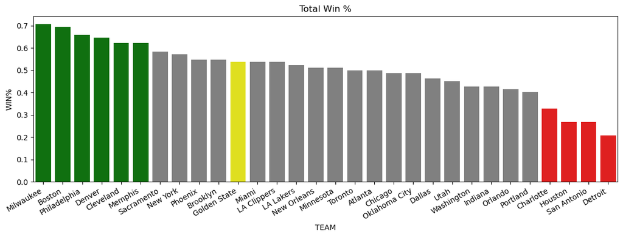

```python
def assign_color(row):
    if row['TEAM'] == 'Golden State':
        return 'yellow'  # Golden State Warriors
    elif row['>60%']:
        return 'green'  # Top teams
    elif row['<40%']:
        return 'red'  # Bottom teams
    else:
        return 'grey'  # All other teams

df = df.sort_values(by=['WIN%'], ascending=False)
df['>60%'] = df['WIN%'] >= 0.6
df['<40%'] = df['WIN%'] <= 0.4
my_palette = df.apply(assign_color, axis=1)
plot = sns.barplot(data=df, x='TEAM', y='WIN%', palette=my_palette)
plt.gcf().set_size_inches(14,4)
plt.title('Total Win %')
plot.set_xticklabels(plot.get_xticklabels(), rotation=30, ha='right')
plot
print(df.loc[df['TEAM'] == 'Golden State', 'WIN%'])
```

```
19    0.805
Name: Home Win%, dtype: float64
```

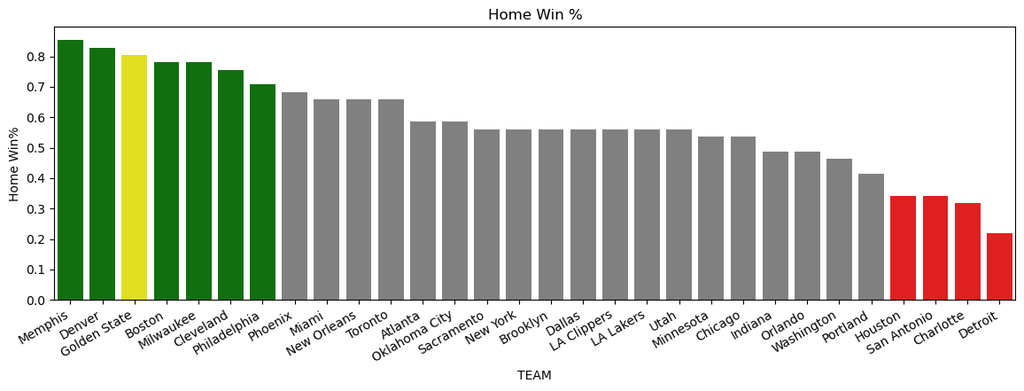

```python
df = df.sort_values(by=['Home Win%'], ascending=False)
my_palette2 = df.apply(assign_color, axis=1)
plot = sns.barplot(data=df, x='TEAM', y='Home Win%', palette=my_palette2)
plt.gcf().set_size_inches(14,4)
plt.title('Home Win %')
plot.set_xticklabels(plot.get_xticklabels(), rotation=30, ha='right')
plot
print(df.loc[df['TEAM'] == 'Golden State', 'Home Win%'])
```

```
19    0.268
Name: Road Win%, dtype: float64
```

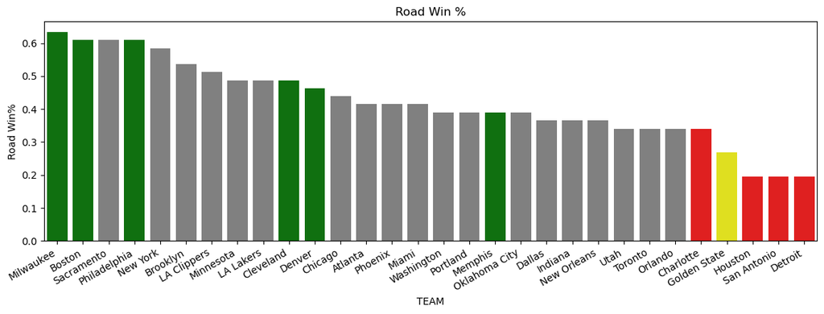

```python
df = df.sort_values(by=['Road Win%'], ascending=False)
my_palette3 = df.apply(assign_color, axis=1)
plot = sns.barplot(data=df, x='TEAM', y='Road Win%', palette=my_palette3)
plt.gcf().set_size_inches(14,4)
plt.title('Road Win %')
plot.set_xticklabels(plot.get_xticklabels(), rotation=30, ha='right')
plot
print(df.loc[df['TEAM'] == 'Golden State', 'Road Win%'])
```

```
19    0.537
Name: Home Road Diff, dtype: float64
```

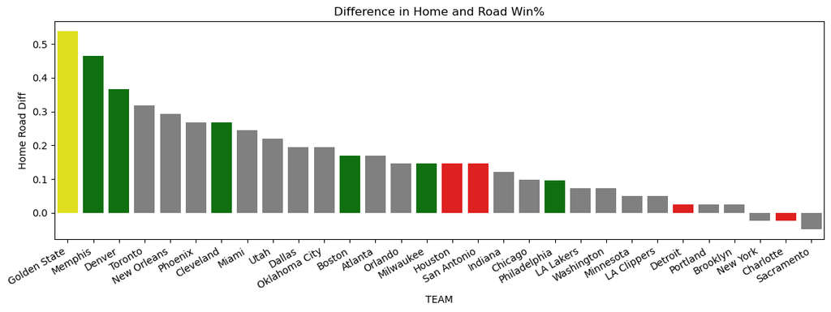

```python
df['Home Road Diff'] = df['Home Win%'] - df['Road Win%']
df = df.sort_values(by=['Home Road Diff'], ascending=False)

my_palette4 = df.apply(assign_color, axis=1)
plot = sns.barplot(data=df, x='TEAM', y='Home Road Diff', palette=my_palette4)
plt.gcf().set_size_inches(14,4)
plt.title('Difference in Home and Road Win%')
plot.set_xticklabels(plot.get_xticklabels(), rotation=30, ha='right')
plot
print(df.loc[df['TEAM'] == 'Golden State', 'Home Road Diff'])
```

### Conclusions:

Looking at the graphs above, we can clearly see that there is some sort of discrepancy going on with Golden State's WP, with Memphis having a quite similar record but not as exaggerated, sitting well over 10% above Golden State in their Road WP.

Now, although there is a visible split in the Golden State Warriors' WP, some concrete numbers indicating that there is something going on would be better. Below, we find the top 5 z-scores of each team's home road diff, essentially just a measurement of how far away a team is from the average home/road split. In our dataframe, GSW is the 19th row, and can be seen to have a z-score of 2.7, with Memphis (16) trailing at 2.19. With a z-score of 2.72, GSW's home/road split is far from the average, indicating pretty definitively that GSW are very unbalanced in their win and loss percentages. Despite Memphis also having a high z-score, GSW is far more extreme than them, an outlier amongst outliers, if you will.

However, our purpose with this analysis does not end at figuring out that there is a discrepancy. That much is pretty clear to see just from the scorelines. We want to figure out **why** the Golden State Warriors have such a discrepancy. Thus, our next steps involve finding the source of this discrepancy, and pinpointing what it is that the Golden State Warriors do right at home but not on the road that causes this gap.

```python
import scipy.stats as stats
df['zscores'] = stats.zscore(df['Home Road Diff'])
print("Top 5 zscores")
print(df.loc[list(zscores.index)[:5]][['TEAM','zscores']])
print("\nBottom 5 zscores")
print(df.loc[list(zscores.index)[-5:]][['TEAM','zscores']])
```

```
Top 5 zscores
            TEAM   zscores
19  Golden State  2.721899
16       Memphis  2.193398
15        Denver  1.483904
8        Toronto  1.136397
23   New Orleans  0.955404

Bottom 5 zscores
          TEAM   zscores
27    Portland -0.984845
5     Brooklyn -0.992085
4     New York -1.339592
13   Charlotte -1.339592
17  Sacramento -1.520585
```

## **Delving Into the Stats: 🤓🤓**

Now that we've established that the Golden State Warriors are out of the ordinary when it comes to their Home-Road split, we naturally arrive on the question "why?"

[figure not shown]

source: https://media.giphy.com/media/1M9fmo1WAFVK0/giphy.gif

Well, to figure that out, our first step is to clean up our data a bit more, removing the values that don't effect the outcome of the game directly.

*For clarity, these stats are: Rank, Team, Conference, Division, Wins, Losses, Achievement Level (difference between actual and expected WP), Consistency Rating (an overall measurement of how consistent a team is game to game). Games Played, and Remaining Strength of the Schedule (how good the teams they havent played are), expected, predicted, and total win percentages, Schedule Adjusted Rating (adjusted evaluation based on strength of schedule)*

Then, we take the average and variance of the entire league and use them to normalize the scores of the Golden State Warriors at home and away. From here, taking the sum of squared differences between the stats of the home and road Golden State Warriors will give us an initial idea of which stats are most different between their home and road games

```python
# # Squared differnce
unimportant_stats = ['RANK', 'TEAM', 'CONF', 'DIVISION','W','L','ACH','CONS','GP','rSOS','eWIN%','pWIN%','WIN%','SAR']
total_stats = both.drop(unimportant_stats, axis=1)
total_stats.loc['stdDeviation'] = total_stats.var()**0.5
total_stats.loc['mean'] = total_stats.mean()

GS_num_home = home.loc[home['TEAM'] == 'Golden State'].drop(unimportant_stats, axis = 1)
GS_num_road = road.loc[road['TEAM'] == 'Golden State'].drop(unimportant_stats, axis = 1)

norm_home = (GS_num_home - total_stats.loc['mean'])/(total_stats.loc['stdDeviation'])
norm_away = (GS_num_road - total_stats.loc['mean'])/(total_stats.loc['stdDeviation'])
ssd = (norm_home.iloc[0] - norm_away.iloc[0])**2
print(ssd)
```

```
PPG       0.289939
oPPG      9.679428
pDIFF     9.378622
PACE      0.051757
oEFF      1.259482
dEFF     14.303481
eDIFF     9.116073
SOS       0.000000
A4F       0.000000
STRK      0.214868
dtype: float64
```

From this we can see that the stats with the most significant differences are oPPG (Points Allowed Per Game), pDiff (Points Differential), dEFF(Defensive Efficiency), and eDIFF (Efficiency Differential).

Seeing the numbers is nice and all, but visualization is the core of understanding. Here are some graphs to show the differences in home and road between each statistic:

### Golden State Standardized Performance (Home vs Road)

This bargraph normalizes the stats Golden State Warriors in a different way, so that we can get a different perspective. using the formula (x - min)/(max - min), we are able to see which statistics have the greatest difference between home and away and which ones aren't all that important for our purposes. As expected, the same stats rise to the surface as having a large difference.

### Points Allowed Per Game vs Win %

This plot visualizes the correlation between points scored by the opposing team and WP for every team in the league. We then calculate the correlation coefficient between the two statistics, showing us that the coefficient is just below 0.7, which is the point where the coefficient is considered significant.

```python
home_max = home.drop(unimportant_stats, axis=1).max()
home_min = home.drop(unimportant_stats, axis=1).min()

road_max = road.drop(unimportant_stats, axis=1).max()
road_min = road.drop(unimportant_stats, axis=1).min()

standard_home = GS_num_home.apply(lambda x: (x - home_min[x.index])/
(home_max[x.index] - home_min[x.index]), axis=1)

standard_road = GS_num_road.apply(lambda x: (x - road_min[x.index])/
(road_max[x.index] - road_min[x.index]), axis=1)
```

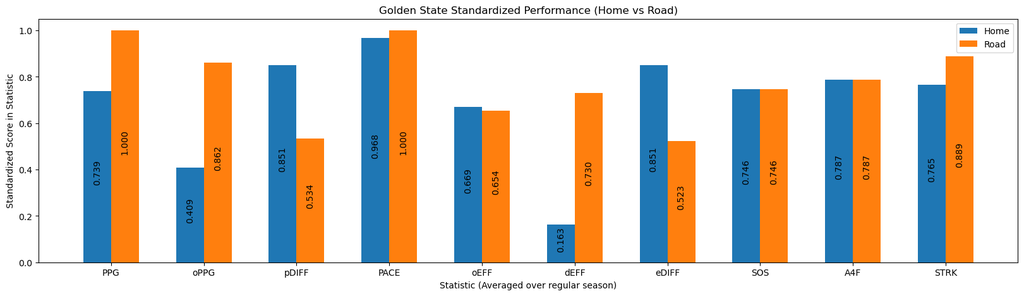

```python
# This plot standardizes the values for each statistic by taking (x - min)/(max - min) for that statistic
# We can see which statistics have great differences between home and away
# Look at https://www.nbastuffer.com/2022-2023-nba-team-stats/ for an explanation of each abreviation
# A number of the statistics that stand out here rely on each other but some don't
# Main one is oPPG and the similar statistics which highlight a bad defense
x = np.arange(10)
width = 0.30

# plot data in grouped manner of bar type
plt.figure(figsize=(20, 5))
plt.bar_label(plt.bar(x-0.15, standard_home.to_numpy()[0], width),
fmt='%.3f', fontsize=10, padding=5, label_type='center', rotation='vertical')

plt.bar_label(plt.bar(x+0.15, standard_road.to_numpy()[0], width),
fmt='%.3f', fontsize=10, padding=5, label_type='center', rotation='vertical')
plt.legend(['Home', 'Road'])
plt.xlabel('Statistic (Averaged over regular season)')
plt.ylabel('Standardized Score in Statistic')
plt.title('Golden State Standardized Performance (Home vs Road)')
""
plt.xticks(x, standard_home.columns)
plt.show()
```

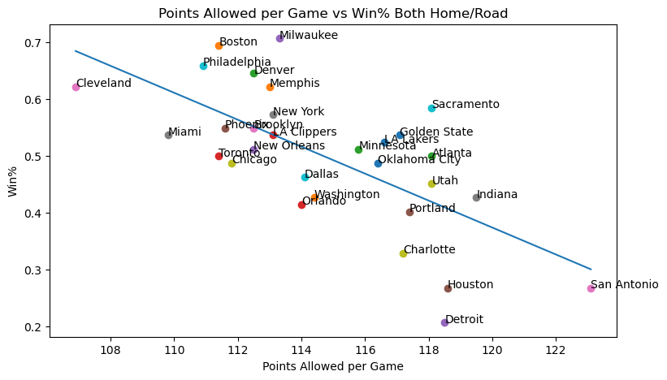

```
-0.6726665721024062
```

```python
# Plot to find how strongly correlated allowing shots and winning are for how and away
# Pearson standard correlation coefficient was calcualted to show how closely these two follow a linear trend
# r=+-0.7 is considered significant
# Split into home vs away below

fig, ax = plt.subplots(figsize = (9,5))
for team in df['TEAM']:
    ax.scatter(df[df['TEAM'] == team]['oPPG'], df[df['TEAM'] == team]['WIN%'])
    ax.annotate(team, (df[df['TEAM'] == team]['oPPG'], df[df['TEAM'] == team]['WIN%']))
ax.set_title('Points Allowed per Game vs Win% Both Home/Road')
ax.set_xlabel('Points Allowed per Game')
ax.set_ylabel('Win%')

y = np.polyfit(df['oPPG'], df['WIN%'], 1)
x = np.linspace(df['oPPG'].min(), df['oPPG'].max())
p = np.poly1d(y)
ax.plot(x,p(x))
plt.show()
print(df['oPPG'].corr(df['WIN%'], method='pearson'))
```

### Points Allowed Per Game vs Win% on Road and Points Allowed per Game vs Win% at Home

These plots are exactly the same as above, but for Win% on Road and Home instead. Looking at the Correlation Coefficients, we can see that the PPG and WP is far more significant in home games versus road games.

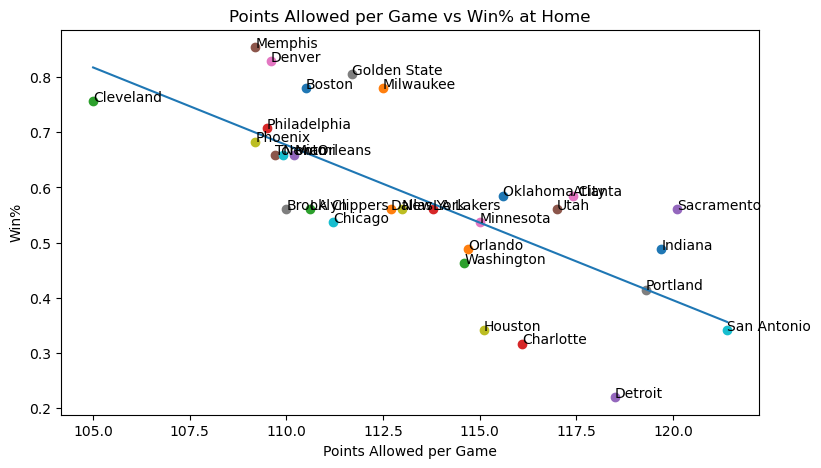

```
-0.716004458989633
```

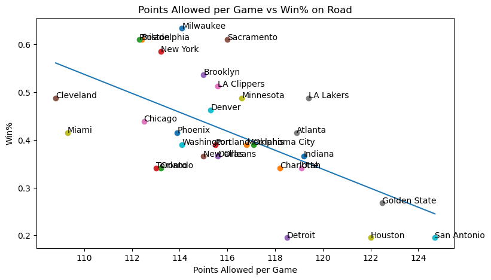

```
-0.5914404011885338
```

```python
# Same as above but now split into home and road to see if correlation strength differs
# We can see the correlation is significant and strong when at home but not as much when on road
# IDK if this helps our argument that it was due to defense so mayb j drop these two plots and keep overall to say that it was significant

fig, ax = plt.subplots(figsize = (9,5))
for team in home['TEAM']:
    ax.scatter(home[home['TEAM'] == team]['oPPG'], home[home['TEAM'] == team]['WIN%'])
    ax.annotate(team, (home[home['TEAM'] == team]['oPPG'], home[home['TEAM'] == team]['WIN%']))
ax.set_title('Points Allowed per Game vs Win% at Home')
ax.set_xlabel('Points Allowed per Game')
ax.set_ylabel('Win%')

y = np.polyfit(home['oPPG'], home['WIN%'], 1)
x = np.linspace(home['oPPG'].min(), home['oPPG'].max())
p = np.poly1d(y)
ax.plot(x,p(x))
plt.show()
print(home['oPPG'].corr(home['WIN%'], method='pearson'))

fig, ax = plt.subplots(figsize = (9,5))
for team in road['TEAM']:
    ax.scatter(road[road['TEAM'] == team]['oPPG'], road[road['TEAM'] == team]['WIN%'])
    ax.annotate(team, (road[road['TEAM'] == team]['oPPG'], road[road['TEAM'] == team]['WIN%']))
ax.set_title('Points Allowed per Game vs Win% on Road')
ax.set_xlabel('Points Allowed per Game')
ax.set_ylabel('Win%')

y = np.polyfit(road['oPPG'], road['WIN%'], 1)
x = np.linspace(road['oPPG'].min(), road['oPPG'].max())
p = np.poly1d(y)
ax.plot(x,p(x))
plt.show()
print(road['oPPG'].corr(road['WIN%'], method='pearson'))
```

## **The Models :** 😈😈

Now we come to the crucial part: the models. We chose to make use of an Ordinary Least Squares model for our purposes, and it should be a pretty good means of identifying whether the stats we pinpointed in the previous sections really can explain the home-road split of the Golden State Warriors.

### Regression 1:

Our first regression is a single variable regression, correlating Win Percentage to the amount of points allowed per game for each team at home. We can see here that the regression actually fits pretty well, showing that there is a pretty strong connection between points allowed per game and win %, even if it isn't the full story.

```python
#Just using oPPG explains a decent amount of
#The Home win %
reg = smf.ols('W ~ oPPG' , data=home).fit()
reg.summary()
```

OLS Regression Results

| Dep. Variable: | W | R-squared: | 0.512 |
| --- | --- | --- | --- |
| Model: | OLS | Adj. R-squared: | 0.495 |
| Method: | Least Squares | F-statistic: | 29.41 |
| Date: | Thu, 11 May 2023 | Prob (F-statistic): | 8.74e-06 |
| Time: | 21:00:31 | Log-Likelihood: | -87.291 |
| No. Observations: | 30 | AIC: | 178.6 |
| Df Residuals: | 28 | BIC: | 181.4 |
| Df Model: | 1 |  |  |
| Covariance Type: | nonrobust |  |  |

|  | coef | std err | t | P>\|t\| | [0.025 | 0.975] |
| --- | --- | --- | --- | --- | --- | --- |
| Intercept | 154.5024 | 24.117 | 6.406 | 0.000 | 105.101 | 203.904 |
| oPPG | -1.1523 | 0.212 | -5.423 | 0.000 | -1.588 | -0.717 |

| Omnibus: | 0.565 | Durbin-Watson: | 1.541 |
| --- | --- | --- | --- |
| Prob(Omnibus): | 0.754 | Jarque-Bera (JB): | 0.632 |
| Skew: | -0.065 | Prob(JB): | 0.729 |
| Kurtosis: | 2.301 | Cond. No. | 3.26e+03 |

Notes:  
[1] Standard Errors assume that the covariance matrix of the errors is correctly specified.  
[2] The condition number is large, 3.26e+03. This might indicate that there are  
strong multicollinearity or other numerical problems.

### Regressions 2 & 3:

In these two regressions we can see that the R2 score is incredibly high when using the statistics we pinpointed by examining the Golden State Warriors on the entire dataset. Its clear that in general there is a very strong correlation between these statistics and winning at home or away in general, and the Golden State Warriors' home-road split can be explained by the massive difference between their home and road performances in each one of these stats.

```python
#Adding all the biggest differences to to the regression. Our R^2 is super high
#So this model explains Wins at home very well.
reg = smf.ols('W ~ oPPG + pDIFF + dEFF + eDIFF' , data=home).fit()
reg.summary()
```

OLS Regression Results

| Dep. Variable: | W | R-squared: | 0.919 |
| --- | --- | --- | --- |
| Model: | OLS | Adj. R-squared: | 0.906 |
| Method: | Least Squares | F-statistic: | 70.99 |
| Date: | Fri, 12 May 2023 | Prob (F-statistic): | 2.80e-13 |
| Time: | 11:22:35 | Log-Likelihood: | -60.345 |
| No. Observations: | 30 | AIC: | 130.7 |
| Df Residuals: | 25 | BIC: | 137.7 |
| Df Model: | 4 |  |  |
| Covariance Type: | nonrobust |  |  |

|  | coef | std err | t | P>\|t\| | [0.025 | 0.975] |
| --- | --- | --- | --- | --- | --- | --- |
| Intercept | 30.5051 | 24.005 | 1.271 | 0.215 | -18.934 | 79.944 |
| oPPG | -0.0053 | 0.194 | -0.028 | 0.978 | -0.404 | 0.393 |
| pDIFF | -4.5152 | 5.095 | -0.886 | 0.384 | -15.009 | 5.978 |
| dEFF | -0.0811 | 0.275 | -0.294 | 0.771 | -0.648 | 0.486 |
| eDIFF | 5.7668 | 5.125 | 1.125 | 0.271 | -4.787 | 16.321 |

| Omnibus: | 0.187 | Durbin-Watson: | 1.843 |
| --- | --- | --- | --- |
| Prob(Omnibus): | 0.911 | Jarque-Bera (JB): | 0.139 |
| Skew: | 0.138 | Prob(JB): | 0.933 |
| Kurtosis: | 2.812 | Cond. No. | 1.07e+04 |

Notes:  
[1] Standard Errors assume that the covariance matrix of the errors is correctly specified.  
[2] The condition number is large, 1.07e+04. This might indicate that there are  
strong multicollinearity or other numerical problems.

```python
#Our R^2 is slightly lower but still very high
#Some difference in siginifcance of variables
reg = smf.ols('L ~ oPPG + pDIFF + dEFF + eDIFF' , data=road).fit()
reg.summary()
```

OLS Regression Results

| Dep. Variable: | L | R-squared: | 0.786 |
| --- | --- | --- | --- |
| Model: | OLS | Adj. R-squared: | 0.752 |
| Method: | Least Squares | F-statistic: | 23.02 |
| Date: | Fri, 12 May 2023 | Prob (F-statistic): | 4.50e-08 |
| Time: | 11:22:40 | Log-Likelihood: | -67.180 |
| No. Observations: | 30 | AIC: | 144.4 |
| Df Residuals: | 25 | BIC: | 151.4 |
| Df Model: | 4 |  |  |
| Covariance Type: | nonrobust |  |  |

|  | coef | std err | t | P>\|t\| | [0.025 | 0.975] |
| --- | --- | --- | --- | --- | --- | --- |
| Intercept | 25.6747 | 31.743 | 0.809 | 0.426 | -39.702 | 91.051 |
| oPPG | -0.1809 | 0.253 | -0.714 | 0.482 | -0.703 | 0.341 |
| pDIFF | 2.9019 | 4.566 | 0.636 | 0.531 | -6.501 | 12.305 |
| dEFF | 0.1402 | 0.358 | 0.391 | 0.699 | -0.598 | 0.878 |
| eDIFF | -4.0693 | 4.553 | -0.894 | 0.380 | -13.447 | 5.308 |

| Omnibus: | 0.348 | Durbin-Watson: | 1.331 |
| --- | --- | --- | --- |
| Prob(Omnibus): | 0.840 | Jarque-Bera (JB): | 0.506 |
| Skew: | 0.187 | Prob(JB): | 0.776 |
| Kurtosis: | 2.485 | Cond. No. | 1.15e+04 |

Notes:  
[1] Standard Errors assume that the covariance matrix of the errors is correctly specified.  
[2] The condition number is large, 1.15e+04. This might indicate that there are  
strong multicollinearity or other numerical problems.

## **In Conclusion:** 🤯🤯

1. We figured out that the Golden State Warriors did indeed have a split unlike any other in the league through visualizations and analysis
2. We pinpointed key differences in between the Golden State Warriors' statistics in between their home and road games, trying to find which ones were the cause.
3. We used machine learning models to figure out how important the statistics that the Golden State Warriors had a large split in were to winning in the 2022-2023 NBA season overall.

Thus, we can conclude that Points Allowed Per Game, Points Differential, Defensive Efficiency, and the Efficiency Differential between offence and defense are critical to winning a game in the NBA, and are the areas in which the Golden State Warriors struggle the most, indicating that rather than their offence, their defensive capabilities become much worse when playing on road versus at home.